# STAT 240 Discussion 11 Solution

## Assignment Completion

If your group does not complete the assignment during discussion, find time to work together outside of class to finish the assignment.

Group 311C: William Fan, Jason Fu, Fei Qin, Nihar Simhadri, Kai Tsuyoshi

## Data

The data set `boston-marathon-2010-sample.csv` contains a random sample of 50 men and 50 women, aged 35–39, who ran in and completed the 2010 Boston Marathon. Times are in minutes.

```r
bm = read_csv("../../data/boston-marathon-2010-sample.csv")
```

## Problems

The questions in this discussion assignment use a subset of the 2010 Boston Marathon data set described above.

### Problem 1

Display the data using side-by-side boxplots with the sex of the competitor on the x axis and their time on the y axis. Add an appropriate title and axis labels to the plot.

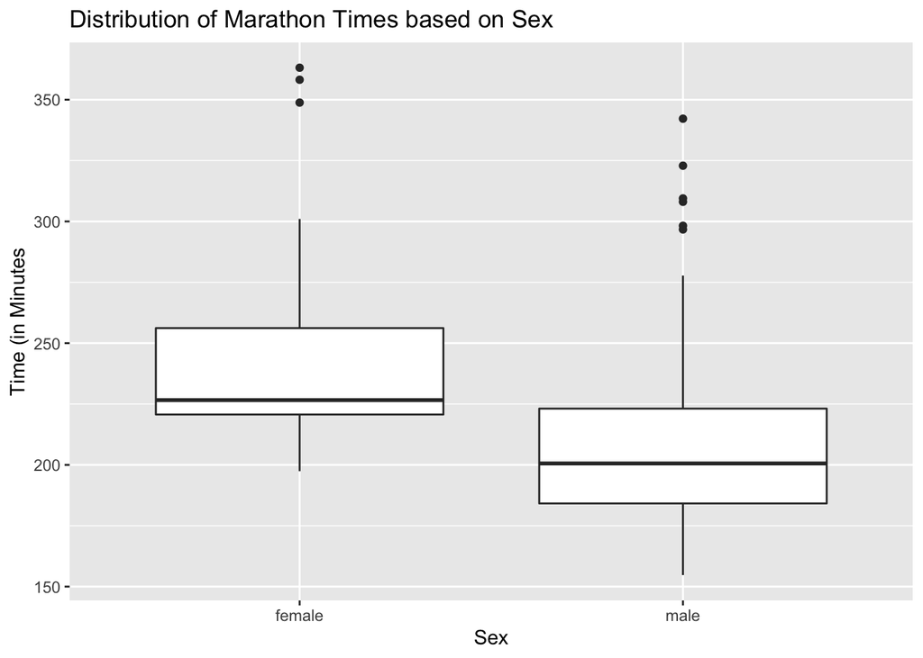

```r
ggplot(bm, aes(x = Sex, y = Time)) +
  geom_boxplot() +
  ggtitle("Distribution of Marathon Times based on Sex") +
  xlab("Sex") +
  ylab("Time (in Minutes")
```

### Problem 2

Create and display a table with a numerical summary of the table. Calculate the sample size, mean time, standard deviation of the times, and standard error of the mean ($s_x/\sqrt{n}$) separately for each sex. This table will have one row for each sex.

```r
tbl = bm %>%
  group_by(Sex) %>%
  summarize(n = n(), mean = mean(Time), sd = sd(Time), se = sd/sqrt(n))

tbl
```

```
## # A tibble: 2 × 5
##   Sex        n  mean    sd    se
##   <chr>  <int> <dbl> <dbl> <dbl>
## 1 female    50  242.  39.3  5.56
## 2 male      50  213.  44.8  6.33
```

### Problem 3

Using the function `t.test()`, construct separate 95% confidence intervals for each sex for the mean time to complete the 2010 Boston Marathon among all competitors of that sex aged 35–39.

```r
# male
x = bm %>%
  filter(Sex == "male") %>%
  select(Time)


t.test(x)
```

```
##
##  One Sample t-test
##
## data:  x
## t = 33.691, df = 49, p-value < 2.2e-16
## alternative hypothesis: true mean is not equal to 0
## 95 percent confidence interval:
##  200.6301 226.0819
## sample estimates:
## mean of x
##   213.356
```

```r
# female
y = bm %>%
  filter(Sex == "female") %>%
  select(Time)


t.test(y)
```

```
##
##  One Sample t-test
##
## data:  y
## t = 43.498, df = 49, p-value < 2.2e-16
## alternative hypothesis: true mean is not equal to 0
## 95 percent confidence interval:
##  230.7624 253.1176
## sample estimates:
## mean of x
##    241.94
```

### Problem 4

Without using the function `t.test()` write code to calculate the end points of the 95% confidence interval for the mean time for women aged 35–39 to complete the 2010 Boston Marathon.
$$t = \frac{\bar{X} - \bar{Y}}{\sqrt{\frac{s_x^2}{n_x} + \frac{s_y^2}{n_y}}}$$

```r
t_mult = qt(0.975, 50-1)

female_mean = tbl %>%
  filter(Sex == "female") %>%
  select(mean)

female_se = tbl %>%
  filter(Sex == "female") %>%
  select(se)

ci = c(female_mean - t_mult * female_se, female_mean + t_mult * female_se)
ci
```

```
## $mean
## [1] 230.7624
##
## $mean
## [1] 253.1176
```

### Problem 5

Write an interpretation of the confidence interval from the previous problem in context, following course examples.

For the sample size of n = 50, we are 95% confident that the mean time for women aged 35–39 to complete the 2010 Boston Marathon is between 230.7 minutes and 253.2 minutes.

### Problem 6

Test the hypothesis that the mean times are equal for men and women to complete the 2010 Boston Marathon among runners aged 35–39 versus the two-sided alternative that they are not.

1. Define parameters and a model
2. State hypotheses
3. Use `t.test()` to do calculations of the test statistic and p-value.

```r
female_mean = bm %>%
  filter(Sex == "female") %>%
  select(Time)
male_mean = bm %>%
  filter(Sex == "male") %>%
  select(Time)
difffe=female_mean-male_mean
meand=mean(difffe$Time)
result=t.test(difffe, mu=meand)
result
```

```
##
##  One Sample t-test
##
## data:  difffe
## t = 0, df = 49, p-value = 1
## alternative hypothesis: true mean is not equal to 28.584
## 95 percent confidence interval:
##  19.1917 37.9763
## sample estimates:
## mean of x
##    28.584
```

### Problem 7

Interpret the results of this hypothesis test in context, following examples from lecture.

### Problem 8

Create a graph using functions from `ggprob.R` to graph the t distribution which is the null distribution of the test statistic. Shade the area under the curve that represents the p-value and add a vertical dashed line at the location of the test statistic.

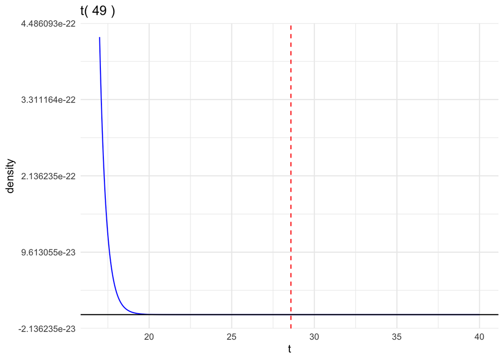

```r
gt(df = 49, a = 17, b = 40) +
  geom_t_fill(df = 49, a = 28.584, b = 40) +
  geom_vline(xintercept = 28.584, color = "red", linetype = "dashed") +
  xlab("t") +
  theme_minimal()
```